# MEV_Analysis_v1

#### Load Libraries

```r
library(ggplot2)
library("dplyr")
library(stargazer)
library(tidyr)
library("readxl")
library("arrow")
library("tseries")
library(scales)
library(reshape)
library(ggbreak)
library(forcats)
library(corrplot)
library(car)
library("nlme")
library("unix")
library("dynlm")
library("sandwich")
library(lmtest)
library(MASS)
library(GGally)
library(xtable)

#rlimit_all() # reading memory limits
#rlimit_as(1e12)  #increases to ~12GB
```

#### Setting input/output directories

```r
options(scipen = 100)
options(scipen = 0) # scietific notation
```

```r
dir <- "/Users/marcvendramet/Documents/GitHub/MV_MEV-thesis/01_R_MEV"
dirplots <- "/Users/marcvendramet/Desktop/HSG/Master/MA/99_Overleaf/02_Plots"
dirInput <- "/Volumes/Extreme SSD"

setwd(dir)
```

#### read data

```r
#dfTransactions <- read_excel("/Users/marcvendramet/Desktop/HSG/Master/MA/99_Overleaf/02_Plots/Su#mStats_UniswapV2Transactions.xlsx", sheet = "Summary")
```

```r
dfMaster <- read.csv(paste0(dirInput, "/97_FinalSet/MEV_finalDataSet_v2.csv"))
```

```r
dfGasFull <- read.csv(paste0(dirInput, "/97_FinalSet/MEV_finalDataSet.csv"))
```

```r
# not used, because we use the data included in the master file
#dfGasFull <- read_parquet(paste0(dirInput, "/01_GasData/GasPriceAll.par"))
#dfGasFull <- read.csv(paste0(dirInput, "/01_GasData/GasPriceAll.csv"))
```

```r
colnames(dfMaster)
```

```r
# Using data pre-outlier handling
dfGas <- subset(dfGasFull, select = c("avg_gas", "median_gas", "threshold_gas", "transaction_count", "price_USD", "total_gasUsed"))
#
```

```r
#dfGas$block_number <- as.numeric(dfGas$block_number)

#df1 <- lapply(dfGas, function(x) {as.numeric(x)})
```

#### Descriptive statistics

Attention: distignuish between for and after outlier handling (done in python for v2)

```r
stargazer(dfGas, digits = 0, align=FALSE ,column.sep.width = "5pt",type = "text" )
```

```r
stargazer(dfGas, digits = 0, align=FALSE ,column.sep.width = "5pt",type =  )
```

#### Plots: gas price from GasPriceAll(v1)

##### Data adjustments

Additinal variable creation

```r
dfGasFull$gasPerTx <- dfGasFull$total_gasUsed/dfGasFull$transaction_count
```

Remove outliers

```r
dfGasFull[dfGasFull$avg_gas > 10000,] %>%
  arrange(desc(avg_gas))

#dfGasFull[dfGasFull$avg_gas > quantile(dfGasFull$avg_gas, probs = c(0.999995)),] %>%
#  arrange(desc(avg_gas))
```

```r
# Alternative: windosrizing https://www.rdocumentation.org/packages/DescTools/versions/0.99.45/topics/Winsorize
dfGasFull$avg_gas_clean <- dfGasFull$avg_gas
dfGasFull$avg_gas_clean[dfGasFull$avg_gas_clean > 10000] <-
  mean(dfGasFull$avg_gas_clean[dfGasFull$avg_gas_clean < 10000])

#dfGasFull$avg_gas_clean[dfGasFull$avg_gas_clean > quantile(dfGasFull$avg_gas, probs = c(0.99999))] <-
#  mean(dfGasFull$avg_gas_clean[dfGasFull$avg_gas_clean < quantile(dfGasFull$avg_gas, probs = c(0.99999))])
```

##### Avg gas price over time

Including otuliers

```r
# https://community.rstudio.com/t/how-to-label-some-vertical-lines-in-ggplot/59560
# https://www.forbes.com/sites/youngjoseph/2020/06/10/why-a-mysterious-crypto-user-paid-26-million-to-send-merely-130-in-ethereum/
# https://insights.glassnode.com/defi-spike-ethereum-gas-price/
ggplot(dfGasFull, aes(x=block_number, y=avg_gas)) + geom_line() +
  geom_line(color="blue") +
  labs(y ="avg_gas in Gwei", x = "Block number") +
  annotate(geom = "vline",
             x = c(10237208),
             xintercept = c(10237208),
             linetype = c("dashed")) +
  annotate(geom = "text",
             label = c("Accidental 2.6m $ gas fee"),
             x = c(10248000),
             y = c(2e6),
             angle = 90,
             vjust = 1)
```

```r
ggsave(filename = "avgGas_overtime.png", path = dirplots, width = 15, height = 8, units = "cm")
```

Excluding otuliers

```r
# https://community.rstudio.com/t/how-to-label-some-vertical-lines-in-ggplot/59560
# https://www.forbes.com/sites/youngjoseph/2020/06/10/why-a-mysterious-crypto-user-paid-26-million-to-send-merely-130-in-ethereum/
ggplot(dfGasFull, aes(x=block_number, y=avg_gas_clean)) +
  geom_line(color="blue") +
  labs(y ="avg_gas in Gwei", x = "Block number") +
  geom_smooth(method = "lm", color = "red")
```

```r
# spike 1: 11912403 2021-02-23, ETh price drop, https://decrypt.co/58533/ethereum-fees-shoot-above-30-amid-sudden-market-dip
# spike 2: 12422680 2021-05-13, ETH ATH https://finance.yahoo.com/news/ethereum-gas-prices-fall-lowest-052059169.html?guccounter=1&guce_referrer=aHR0cHM6Ly93d3cuZ29vZ2xlLmNvbS8&guce_referrer_sig=AQAAABFmU_LIF4-A9a6J5w9b7Zv12_kOLZV7AKtZQC5clBa3-fYiXEorAY9zrzDSdUMC_qTwWhDdt3ds41akUtBE4Dzjl0gNoDE5Mel0DY8P9ksjxx9xVUitwNJSMJaQ9oSxUDS_Jd6ntg3ZR7N_vzLvqSHHQWGy9FbT4XJSebR6vGaG
ggplot(dfGasFull, aes(x=block_number, y=avg_gas_clean)) +
  geom_point(color="blue", size = 0.5) +
  labs(y ="avg_gas in Gwei", x = "Block number") +
  geom_smooth(method = "lm", color = "red") +
  annotate(geom = "vline",
             x = c(11912403, 12470645),
             xintercept = c(11912403, 12470645),
             linetype = c("dashed")) +
  annotate(geom = "text",
             label = c("12% ETH dip", "ETH ATH"),
             x = c(11952403, 12500645),
             y = c(3000,3000),
             angle = 90,
             vjust = 1)
```

```r
ggsave(filename = "avgGasClean_overtime.png", path = dirplots, width = 15, height = 8, units = "cm")
```

##### Median gas usage over time

```r
ggplot(dfGasFull, aes(x=block_number, y= median_gas)) +
  geom_point(color="blue") +
  labs(y ="avg_gas in Gwei", x = "Block number") +
  geom_smooth(method = "lm", color = "red")
```

```r
ggsave(filename = "medianGas_overtime.png", path = dirplots, width = 15, height = 8, units = "cm")
```

##### Threshold gas usage over time

```r
ggplot(dfGasFull, aes(x=block_number, y= threshold_gas)) +
  geom_point(color="blue") +
  labs(y ="avg_gas in Gwei", x = "Block number") +
  geom_smooth(method = "lm", color = "red")
```

```r
ggsave(filename = "thresholdGas_overtime.png", path = dirplots, width = 15, height = 8, units = "cm")
```

##### gas usage over time

```r
ggplot(dfGasFull, aes(x=block_number, y=gasPerTx)) + geom_line() +
  geom_line(color="blue") +
  labs(y ="Average gas used per transaction", x = "Block number") +
  geom_smooth(method = "lm", color = "red")
```

```r
ggsave(filename = "averageGasUsage.png", path = dirplots, width = 15, height = 8, units = "cm")
```

#### Plots: final_set

##### load MEV_Final v2

```r
#rm(dfMaster, dfMasterAttack)
dfMasterAll <- read.csv(paste0(dirInput, "/97_FinalSet/MEV_finalDataSet_v2.csv"))
dfMasterAll$X <- NULL
```

```r
dfMasterAll$ts <- as.Date(dfMasterAll$ts)
```

```r
dfMasterAll$attacks_GasFee_ETH <- dfMasterAll$attacks_GasFee_Gwei / 1000000000
```

```r
colnames(dfMasterAll)
```

```
 [1] "block_number"              "tot_gas"                   "avg_gas"
 [4] "median_gas"                "ts"                        "threshold_gas"
 [7] "total_gasUsed"             "total_gasFee_Gwei"         "total_gasFee_ETH"
[10] "attacks_GasFee_Gwei"       "attacks_GasUsed"           "AttackCount"
[13] "ProxyTransactions_Count"   "ProxyAttacks_Count"        "ProxyAttack_Share"
[16] "attacks_gasPrice_min"      "attacks_gasPrice_max"      "attacks_gasPrice_avg"
[19] "difficulty"                "transaction_count"         "price_USD"
[22] "ts_EthPrice"               "price_USD_delta"           "time_delta"
[25] "price_USD_MA5"             "price_USD_MA30min"         "price_USD_MA24h"
[28] "transaction_count_block"   "AttackCount_10k"           "ProxyAttacks_Count_10k"
[31] "ProxyAttack_Share_10k"     "attacks_GasFeePerAttack"   "attacks_AttackGasFeeShare"
[34] "flashbots_Flag"            "tsDT"                      "Month"
[37] "WeekNumber"                "Weekyday"                  "Hour"
[40] "attacks_GasFee_ETH"
```

##### Descriptive stats

```r
dfMasterAll_selected <- subset(dfMasterAll, select = c("AttackCount", "total_gasFee_ETH", "attacks_GasFee_ETH", "attacks_AttackGasFeeShare", "attacks_gasPrice_min", "attacks_gasPrice_max","attacks_gasPrice_avg"))
stargazer(dfMasterAll_selected, digits = 5, align=FALSE ,column.sep.width = "5pt",type = "text" )
```

##### Number of attacks over time

```r
# adding time labels: https://stackoverflow.com/questions/30018187/changing-tick-intervals-when-x-axis-values-are-dates
# drop in may 2021 due to uniswap v3
ggplot(dfMasterAll, aes(x=ts, y=AttackCount_10k)) +
  geom_line(color="blue") +
  labs(y ="Attack count per 10k blocks", x = "Date") +
  geom_smooth(method = "lm", color = "red") +
  scale_x_date(date_breaks = "months" , date_labels = "%b-%y")
```

```r
ggsave(filename = "MA10k_NrAttacks_date.png", path = dirplots, width = 15, height = 8, units = "cm")
```

```r
dfMasterAll %>% count(AttackCount, sort = TRUE) %>% arrange(desc(n))
```

```r
# adding time labels: https://stackoverflow.com/questions/30018187/changing-tick-intervals-when-x-axis-values-are-dates
ggplot(dfMasterAll, aes(x=block_number, y=AttackCount_10k)) +
  geom_line(color="blue") +
  labs(y ="Attack count per 10k blocks", x = "Block number") +
  geom_smooth(method = "lm", color = "red")
```

```r
ggsave(filename = "MA10k_NrAttacks_blocknr.png", path = dirplots, width = 15, height = 8, units = "cm")
```

```r
ggplot(dfMasterAll, aes(x=block_number, y=AttackCount)) +
  geom_point(color="blue", size = 0.5) +
  labs(y ="Total number of attacks per block", x = "Block number")
```

```r
ggsave(filename = "NrAttacks_block.png", path = dirplots, width = 15, height = 8, units = "cm")
```

Subset creation to filter out block with zero attacks

```r
dfHistogram <- dfMasterAll %>% filter(AttackCount > 0)
```

```r
ggplot(dfHistogram, aes(x= AttackCount)) +
  geom_histogram(binwidth=1, color='blue',fill='blue', alpha=0.3) +
  labs(y ="Count", x = "Attacks per block") +
  scale_x_continuous(limits = c(0,11), breaks=seq(0,10,1))+
  scale_y_continuous(labels = comma)
```

```r
ggsave(filename = "NrAttacks_Histogram.png", path = dirplots, width = 15, height = 8, units = "cm")
```

##### GasFees for attacks over time

```r
# explanation for drop in April 2021 is adoption of flashbots, see p.9 "A Flash(bot) in the Pan: Measuring Maximal Extractable Value in Private Pools"
# adding time labels: https://stackoverflow.com/questions/30018187/changing-tick-intervals-when-x-axis-values-are-dates
ggplot(dfMasterAll, aes(x=block_number, y=attacks_GasFee_ETH)) +
  geom_point(color="blue", size = 0.5) +
  labs(y ="Gas fees from attacks (ETH)", x = "Block number")  +
  annotate(geom = "vline",
             x = c(12200000),
             xintercept = c(12200000),
             linetype = c("dashed")) +
  annotate(geom = "text",
             label = c("Adoption of flashbots"),
             x = c(12250000),
             y = c(4),
             angle = 90,
             vjust = 1)+
  geom_smooth(method = "lm", color = "red")
```

```r
ggsave(filename = "GasFees_attacks_ETH.png", path = dirplots, width = 15, height = 8, units = "cm")
```

##### Avg GasFees per attack over time

For average calculation before anda fter flashbots:

```r
a <- dfMasterAll %>%
  group_by(flashbots_Flag) %>%
  summarise(SumAttackFees = sum(attacks_GasFee_ETH))
```

```r
b <- dfMasterAll %>%
  group_by(flashbots_Flag) %>%
  summarise(SumAttackCount = sum(AttackCount))
```

```r
a$SumAttackFees / b$SumAttackCount
```

```
[1] 0.04957492 0.01729542
```

```r
# returns avergae gas fee per attack per flashbot dummy in ETH
```

For plots:

```r
dfMasterAll$attacks_GasFeePerAttack <- dfMasterAll$attacks_GasFee_ETH / dfMasterAll$AttackCount
dfMasterAll$attacks_GasFeePerAttack <- dfMasterAll$attacks_GasFeePerAttack %>% replace_na(0)
```

```r
dfGasFees <- dfMasterAll[!(dfMasterAll$AttackCount==0),]
```

```r
dfGasFees <- dfGasFees %>%
  arrange(block_number) %>%
    mutate(MA_gasFee = rollmean(attacks_GasFeePerAttack, k = 100, fill = NA, align = "right"))
```

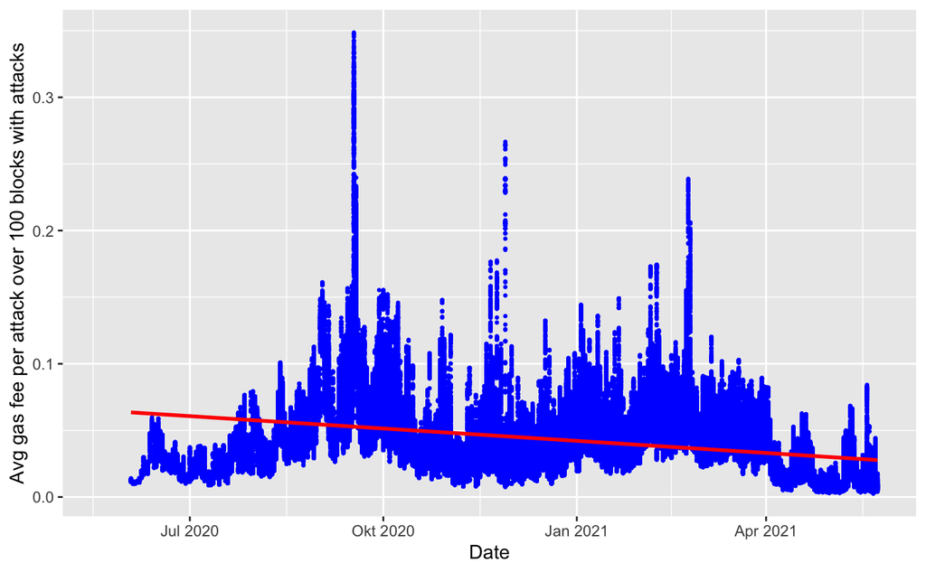

```r
# adding time labels: https://stackoverflow.com/questions/30018187/changing-tick-intervals-when-x-axis-values-are-dates
ggplot(dfGasFees, aes(x=ts, y=MA_gasFee)) +
  geom_point(color="blue", size = 0.5) +
  labs(y ="Avg gas fee per attack over 100 blocks with attacks", x = "Date") +
  geom_smooth(method = "lm", color = "red")
```

```r
  #
```

```r
ggsave(filename = "MA100GasFeeperAttack.png", path = dirplots, width = 15, height = 10, units = "cm")
```

##### AVG GasPrice for attacks over time

```r
# adding time labels: https://stackoverflow.com/questions/30018187/changing-tick-intervals-when-x-axis-values-are-dates
ggplot(dfMasterAll, aes(x=ts, y=attacks_gasPrice_avg)) +
  geom_line(color="blue") +
  labs(y ="Average gas price from attacks (Gwei)", x = "Block number")
  #geom_smooth(method = "lm", color = "red")
```

```r
ggsave(filename = "GasPrice_attacks_gwei.png", path = dirplots, width = 15, height = 8, units = "cm")
```

##### Gas usage per attack over time

```r
dfMasterAll$attacks_GasUsedPerAttack <- dfMasterAll$attacks_GasUsed / dfMasterAll$AttackCount
dfMasterAll$attacks_GasUsedPerAttack <- dfMasterAll$attacks_GasUsedPerAttack %>% replace_na(0)
```

```r
dfGasUsage <- dfMasterAll[!(dfMasterAll$AttackCount==0),]
```

```r
dfGasUsage <- dfGasUsage %>%
  arrange(block_number) %>%
    mutate(MA_gasUsage = rollmean(attacks_GasUsedPerAttack, k = 100, fill = NA, align = "right"))
```

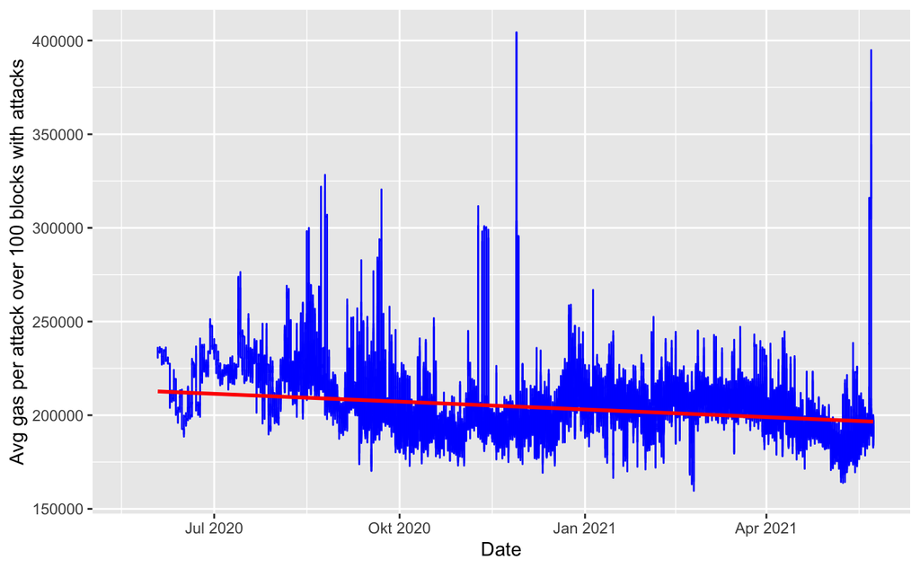

```r
# adding time labels: https://stackoverflow.com/questions/30018187/changing-tick-intervals-when-x-axis-values-are-dates
ggplot(dfGasUsage, aes(x=ts, y=MA_gasUsage)) +
  geom_line(color="blue") +
  labs(y ="Avg gas per attack over 100 blocks with attacks", x = "Date") +
  geom_smooth(method = "lm", color = "red")
```

```r
  #
```

```r
ggsave(filename = "MA100GasUsedperAttack.png", path = dirplots, width = 15, height = 10, units = "cm")
```

```r
ggplot(dfGasUsage, aes(x= attacks_GasUsedPerAttack)) +
  geom_histogram(color='blue',fill='blue', alpha=0.3, bins = )
```

```r
ggsave(filename = "GasUsedPerAttack.png", path = dirplots, width = 15, height = 8, units = "cm")
```

##### Gas fee share

```r
ggplot(dfMasterAll, aes(x=ts, y=attacks_AttackGasFeeShare)) +
  geom_line(color="blue") +
  labs(y ="Gas fee share of attacks (%)", x = "Block number")
  #geom_smooth(method = "lm", color = "red")
```

```r
ggplot(dfMasterAll, aes(x=ts, y=attacks_AttackGasFeeShare)) +
  geom_point(color="blue", size = 0.5) +
  labs(y ="Gas fee share of attacks (%)", x = "Block number")
  #geom_smooth(method = "lm", color = "red")
```

```r
ggsave(filename = "GasFeeShhare_attacks_percentage.png", path = dirplots, width = 15, height = 8, units = "cm")
```

##### Gas fee share histogram

With zero attack blocks

```r
ggplot(dfMasterAll, aes(x= attacks_AttackGasFeeShare)) +
  geom_histogram(color='blue',fill='blue', alpha=0.3, bins = 50) +
  labs(y ="Count", x = "Gas fee share of attacks (%)") +
  scale_y_break(c(500000, 1800000), ticklabels = c(1800000,1900000, 2000000)) +
  scale_y_continuous(labels = comma)
  #scale_x_continuous(limits = c(0,10), breaks=seq(0,10,1))+
  #scale_y_continuous(labels = comma)
```

```r
ggsave(filename = "GasFeeShhare_attacks_Histogram.png", path = dirplots, width = 15, height = 8, units = "cm")
```

Only blocks with attacks

```r
#remove blocks without attacks
dfAttacksOnly <- dfMasterAll[!(dfMasterAll$AttackCount==0),]
```

```r
mean(dfMasterAll$attacks_AttackGasFeeShare)
```

Mean of gas fee share without zero attack blocks

```r
mean(dfAttacksOnly$attacks_AttackGasFeeShare)
```

```r
ggplot(dfAttacksOnly, aes(x= attacks_AttackGasFeeShare)) +
  geom_histogram(color='blue',fill='blue', alpha=0.3, bins = 50) +
  labs(y ="Count", x = "Gas fee share of attacks (%)") +
  scale_y_continuous(labels = comma)
  #scale_x_continuous(limits = c(0,10), breaks=seq(0,10,1))+
  #scale_y_continuous(labels = comma)
```

```r
ggsave(filename = "GasFeeShare_attacksOnly_Histogram.png", path = dirplots, width = 15, height = 8, units = "cm")
```

##### Multiple lines: attack gasfees, total gasfees (remove outlier oversvation based on avg ags price), ratio

Subset creation to filter out block with zero share

```r
#dfHistogramShare <- dfMasterAll %>% filter(attacks_AttackGasFeeShare > 0)
```

```r
dfMultiLine <- subset(dfMasterAll, select = c("block_number", "attacks_AttackGasFeeShare", "total_gasFee_ETH"))
```

```r
#dfMultiLine <- melt(dfMultiLine, id.vars = "block_number") # trasnfroming to long format, but only if same scale for variables
dfMultiLine<-dfMultiLine[!(dfMultiLine$total_gasFee_ETH>100 ),]
```

```r
#ggplot(dfMultiLine, aes(x = block_number, y = value, color = variable)) +
#  geom_line()
```

```r
# Outliers removed, see above
# https://r-graph-gallery.com/line-chart-dual-Y-axis-ggplot2.html
coeff <- max(dfMultiLine$total_gasFee_ETH)

ggplot(dfMultiLine, aes(x=block_number)) +
  geom_line( aes(y=attacks_AttackGasFeeShare),color="blue") +
  geom_line( aes(y=total_gasFee_ETH/coeff), color="coral4",alpha=0.3) +
  labs(x = "Block number") +
  scale_y_continuous(
    name = "Gas fee share of attacks (%)",
    sec.axis = sec_axis(~ . *coeff, name = "Total gas fees per block (ETH)"))+
   theme(axis.title.y = element_text(color = "blue", size=13), axis.title.y.right=element_text(color = "coral4", size=13))
```

```r
ggsave(filename = "GasFeeShareAndtotalFee_Multiline.png", path = dirplots, width = 15, height = 8, units = "cm")
```

##### GasFees-ratio attack Vs total over time

```r
# adding time labels: https://stackoverflow.com/questions/30018187/changing-tick-intervals-when-x-axis-values-are-dates
ggplot(dfMasterAll, aes(x=block_number, y=attacks_AttackGasFeeShare)) +
  geom_line(color="blue") +
  labs(y ="Gas fee share of attacks (%)", x = "Block number") +
  geom_smooth(method = "lm", color = "red", formula = y ~ x + I(x^2))
```

##### GasFees avg per attack before and after flashbots

```r
#remove blocks without attacks
dfFlashbots <- dfMasterAll[!(dfMasterAll$AttackCount==0),]
```

```r
dfFlashbots %>%
  group_by(flashbots_Flag) %>%
  summarize(Mean = mean(attacks_GasFeePerAttack, na.rm=TRUE)) %>%
  ggplot(aes(x=factor(flashbots_Flag), y=Mean)) +
  geom_col(color='blue',fill='blue', alpha=0.3) +
  scale_y_continuous(labels = comma) +
  labs(y ="Mean gas fee per attack (Gwei)", x = "Flashbots active No/Yes")
```

```r
ggsave(filename = "GasFeeFlashbots.png", path = dirplots, width = 15, height = 8, units = "cm")
```

#### Plots: AttackMaster data set and MEV_Final

Attention: Check if Attacjk Master Vs. AttackMaster_Full makes more sense!

```r
#rm(dfMaster, dfMasterAll)
dfMasterAttack <- read_parquet(paste0(dirInput, "/98_Output/AttacksUniswapV2_Master_v2.par"))
#dfMasterAttack$X <- NULL
```

```r
colnames(dfMasterAttack)
```

##### Top 15 assets /tokens

```r
dfMasterAttack %>%
  count(tf_tokenAddress, sort = TRUE) %>%
  arrange(desc(n))%>%
  head(15)
```

```r
dfMasterAttack %>%
  count(tf_tokenAddress, sort = TRUE) %>%
  arrange(desc(n))%>%
  head(15)%>%
  ggplot(aes(x=fct_rev(fct_reorder(tf_tokenAddress, n)),y=n)) +
  geom_col(color='blue',fill='blue', alpha=0.3) + theme(axis.text.x = element_text(angle = 90)) +
  scale_x_discrete(label=function(x) stringr::str_trunc(x, 20))+
  labs(y ="Count", x = "Token address")
  #scale_x_discrete(label=function(x) abbreviate(x, minlength=15))
#function(x) stringr::str_trunc(x, 12)
```

```r
ggsave(filename = "Top15Tokens.png", path = dirplots, width = 15, height = 8, units = "cm")
```

```r
dfMasterAttack %>%
  count(poolId, sort = TRUE) %>%
  arrange(desc(n))%>%
  head(15)
```

##### Top 15 LPs

```r
dfMasterAttack %>%
  count(poolId, sort = TRUE) %>%
  arrange(desc(n))%>%
  head(15)
```

```r
dfMasterAttack %>%
  count(poolId, sort = TRUE) %>%
  arrange(desc(n))%>%
  head(15)%>%
  ggplot(aes(x=fct_rev(fct_reorder(poolId, n)),y=n)) +
  geom_col(color='blue',fill='blue', alpha=0.3) + theme(axis.text.x = element_text(angle = 90)) +
  scale_x_discrete(label=function(x) stringr::str_trunc(x, 20))+
  labs(y ="Count", x = "Liquidty pool address")
  #scale_x_discrete(label=function(x) abbreviate(x, minlength=15))
#function(x) stringr::str_trunc(x, 12)
```

```r
ggsave(filename = "Top15LPs.png", path = dirplots, width = 15, height = 8, units = "cm")
```

##### Top 15 Attackers

```r
#remove second attack transaction
dfTopAttackers <- dfMasterAttack[!(dfMasterAttack$within_transaction_order==2),]
```

```r
dfTopAttackers %>%
  count(from_address, sort = TRUE) %>%
  arrange(desc(n))%>%
  head(15)
```

```r
# nr.1 is 0xf6da21E95D74767009acCB145b96897aC3630BaD Ethhermine MEV sender
# nr.2 is 0x7A08eD5862ba4c2887Ef169A17637EADb27bEEcF proxy contract with funny comments
dfTopAttackers %>%
  count(from_address, sort = TRUE) %>%
  arrange(desc(n))%>%
  head(15)%>%
  ggplot(aes(x=fct_rev(fct_reorder(from_address, n)),y=n)) +
  geom_col(color='blue',fill='blue', alpha=0.3) + theme(axis.text.x = element_text(angle = 90)) +
  scale_x_discrete(label=function(x) stringr::str_trunc(x, 20))+
  labs(y ="Count", x = "Attacker origin address")
  #scale_x_discrete(label=function(x) abbreviate(x, minlength=15))
#function(x) stringr::str_trunc(x, 12)
```

```r
ggsave(filename = "Top15Attackers.png", path = dirplots, width = 15, height = 8, units = "cm")
```

##### Proxy-attacks count over time

```r
#remove blocks without attacks
dfProxyShare <- dfMasterAll[!(dfMasterAll$AttackCount==0),]
```

```r
# niot surprising as 95% of all attacks are proxy-based
ggplot(dfMasterAll, aes(x=block_number, y=ProxyAttacks_Count_10k)) + # use ts for months
  geom_line(color="blue") +
  labs(y ="Proxy attack count per 10k blocks", x = "Block number") +
  geom_smooth(method = "lm", color = "red")
  #scale_x_date(date_breaks = "months" , date_labels = "%b-%y")
```

```r
ggsave(filename = "ProxyAttackMA_overTime.png", path = dirplots, width = 15, height = 8, units = "cm")
```

##### Proxy-attacks share over time

```r
# Almost no zero values - mistake or auto filtered out? see histogram
# why does it behave like thhe attacks overall? should have differnet movement => because the blocks without attacks lead to this
ggplot(dfMasterAll, aes(x=block_number, y=ProxyAttack_Share_10k)) + # use ts for months
  geom_line(color="blue") +
  labs(y ="Attack count per 10k blocks", x = "Date") +
  geom_smooth(method = "lm", color = "red")
  #scale_x_date(date_breaks = "months" , date_labels = "%b-%y")
```

```r
ggsave(filename = "ProxyAttackShareMA_overTime.png", path = dirplots, width = 15, height = 8, units = "cm")
```

```r
# Almost no zero values - mistake or auto filtered out? see histogram
# why does it behave like thhe attacks overall? should have differnet movement
ggplot(dfProxyShare, aes(x=block_number, y=ProxyAttack_Share)) + # use ts for months
  geom_line(color="blue") +
  labs(y ="Attack count per 10k blocks", x = "Date") +
  geom_smooth(method = "lm", color = "red")
  #scale_x_date(date_breaks = "months" , date_labels = "%b-%y")
```

##### Proxy-attacks share histogram

Mean over all blcoks incl. block without attacks

```r
mean(dfMasterAll$ProxyAttack_Share)
```

10k MA

```r
ggplot(dfMasterAll, aes(x= ProxyAttack_Share_10k)) +
  geom_histogram(bins = 10, color='blue',fill='blue', alpha=0.3) +
  labs(y ="Count", x = "Attacks per block")
  #scale_x_continuous(limits = c(0,10), breaks=seq(0,10,1))+
  #scale_y_continuous(labels = comma)
```

```r
ggsave(filename = "ProxyAttackShareMA_Histogram.png", path = dirplots, width = 15, height = 8, units = "cm")
```

Mean with only blocks that contain attacks

```r
mean(dfProxyShare$ProxyAttack_Share)
```

Zero blocks already filtered out

```r
ggplot(dfProxyShare, aes(x= ProxyAttack_Share)) +
  geom_histogram(bins = 8, color='blue',fill='blue', alpha=0.3) +
  labs(y ="Count", x = "Attacks per block") +
  scale_y_continuous(labels = comma)
  #scale_x_continuous(limits = c(0,10), breaks=seq(0,10,1))+
  #
```

##### Different proxy contarcts and attack count

Different proxy contracts

```r
dfMasterAttack %>%
  filter(ProxyFlag == 1) %>%
  filter(within_transaction_order == 1) %>%
  count(from_address, sort = TRUE) %>%
  arrange(desc(n))
  #group_by(from_address) %>%
  #summarize(n = n_distinct(from_address))
```

##### Attacks with gas price <= 1 (MEV-relay proxy) Count

```r
dfMasterAttack %>%
  mutate(trans_gasPrice = replace(trans_gasPrice, trans_gasPrice<=1, 0)) %>%
  mutate(trans_gasPrice = replace(trans_gasPrice, trans_gasPrice>1, 1)) %>%
  group_by(trans_gasPrice) %>%
  ggplot(aes(x=factor(trans_gasPrice))) +
  geom_bar(color='blue',fill='blue', alpha=0.3) +
  scale_y_continuous(labels = comma) +
  labs(y ="Count", x = "MEV-relay used Yes/No")
```

```r
ggsave(filename = "MEVRelay_Histogram.png", path = dirplots, width = 15, height = 8, units = "cm")
```

##### Attacks with gas price <= 1 (MEV-relay proxy) Over time => WIP

```r
#remove blocks without attacks
dfMEVRelay <- dfMasterAttack
```

```r
 dfMasterAttack %>%
  mutate(trans_gasPrice = replace(trans_gasPrice, trans_gasPrice<=1, 0)) %>%
  mutate(trans_gasPrice = replace(trans_gasPrice, trans_gasPrice>1, 1)) %>%
  filter(trans_gasPrice == 0) %>%
  count(block_number, sort = TRUE) %>%
  ggplot(aes(x=block_number, y=n)) + # use ts for months
  geom_line(color="blue") +
  labs(y ="Proxy attack count per 10k blocks", x = "Block number") +
  geom_smooth(method = "lm", color = "red")
```

#### Regression Analysis

##### Load MEV_Final_v2 and subset variables

```r
dfRegression <- read.csv("/Volumes/Extreme SSD/97_FinalSet/MEV_Regression_v1.csv")
dfRegressionSmall <- read.csv("/Volumes/Extreme SSD/97_FinalSet/MEV_RegressionSmall_v1.csv")
# factor transfromation to be done after import!
```

OR

```r
#rm(dfMaster, dfMasterAttack)
dfMasterAll <- read.csv(paste0(dirInput, "/97_FinalSet/MEV_finalDataSet_v2.csv"))
dfMasterAll$X <- NULL
```

```r
# add ID column without gaps for gls() function
dfMasterAll$IDSeq <- seq.int(nrow(dfMasterAll))
```

```r
#confert to dateformat including time. Attention: as.Date removes time component
dfMasterAll$tsDateTime <- as.POSIXct(dfMasterAll$ts, format="%Y-%m-%d%H:%M:%S")
dfMasterAll$tsDate <- as.Date(dfMasterAll$ts)
```

```r
str(dfMasterAll)
```

```
'data.frame':   2346702 obs. of  42 variables:
 $ block_number             : int  10093070 10093071 10093072 10093073 10093074 10093075 10093076 10093077 10093078 10093079 ...
 $ tot_gas                  : int  22817345 37810488 19912767 43009981 26796744 52244849 57310752 30347939 72758735 32516615 ...
 $ avg_gas                  : num  34.4 38 66.2 23.7 41.6 ...
 $ median_gas               : num  20 20 31.9 18 20 ...
 $ ts                       : chr  "2020-05-19 00:00:32" "2020-05-19 00:00:59" "2020-05-19 00:01:04" "2020-05-19 00:01:29" ...
 $ threshold_gas            : num  16.5 16.5 6 16 16 16 16 16 16 16 ...
 $ total_gasUsed            : int  9992145 9988660 9996320 9981147 9977063 9970237 9968071 9970237 9994447 9971557 ...
 $ total_gasFee_Gwei        : num  2.91e+08 2.78e+08 3.74e+08 2.46e+08 3.03e+08 ...
 $ total_gasFee_ETH         : num  0.291 0.278 0.374 0.246 0.303 ...
 $ attacks_GasFee_Gwei      : num  0 0 0 0 0 0 0 0 0 0 ...
 $ attacks_GasUsed          : int  0 0 0 0 0 0 0 0 0 0 ...
 $ AttackCount              : num  0 0 0 0 0 0 0 0 0 0 ...
 $ ProxyTransactions_Count  : num  0 0 0 0 0 0 0 0 0 0 ...
 $ ProxyAttacks_Count       : num  0 0 0 0 0 0 0 0 0 0 ...
```

[output cut: 28 more lines]

```r
dfMasterAll$attacks_GasFee_ETH <- dfMasterAll$attacks_GasFee_Gwei / 1000000000
```

```r
# scale difficulty 0-1
dfMasterAll$difficulty_MaxMin <- (dfMasterAll$difficulty - min(dfMasterAll$difficulty)) / (max(dfMasterAll$difficulty) - min(dfMasterAll$difficulty))  # Scale to 0/1
```

```r
# log transform difficulty
dfMasterAll$difficulty_log <- log(dfMasterAll$difficulty)
```

```r
colnames(dfMasterAll)
```

```
 [1] "block_number"              "tot_gas"                   "avg_gas"
 [4] "median_gas"                "ts"                        "threshold_gas"
 [7] "total_gasUsed"             "total_gasFee_Gwei"         "total_gasFee_ETH"
[10] "attacks_GasFee_Gwei"       "attacks_GasUsed"           "AttackCount"
[13] "ProxyTransactions_Count"   "ProxyAttacks_Count"        "ProxyAttack_Share"
[16] "attacks_gasPrice_min"      "attacks_gasPrice_max"      "attacks_gasPrice_avg"
[19] "difficulty"                "transaction_count"         "price_USD"
[22] "ts_EthPrice"               "price_USD_delta"           "time_delta"
[25] "price_USD_MA5"             "price_USD_MA30min"         "price_USD_MA24h"
[28] "transaction_count_block"   "AttackCount_10k"           "ProxyAttacks_Count_10k"
[31] "ProxyAttack_Share_10k"     "attacks_GasFeePerAttack"   "attacks_AttackGasFeeShare"
[34] "flashbots_Flag"            "tsDT"                      "Month"
[37] "WeekNumber"                "Weekyday"                  "Hour"
[40] "IDSeq"                     "tsDateTime"                "tsDate"
[43] "attacks_GasFee_ETH"        "difficulty_MaxMin"         "difficulty_log"
```

```r
dfRegression <- subset(dfMasterAll, select = c("IDSeq","block_number", "avg_gas", "median_gas", "threshold_gas", "attacks_GasFee_Gwei", "attacks_GasFee_ETH", "attacks_GasUsed", "AttackCount", "attacks_gasPrice_max", "attacks_gasPrice_avg", "attacks_AttackGasFeeShare" ,"difficulty", "price_USD_delta", "transaction_count_block", "AttackCount_10k", "flashbots_Flag", "Month", "WeekNumber", "Weekyday", "Hour", "tsDateTime", "difficulty_MaxMin", "difficulty_log"))
```

```r
dfRegression <- dfRegression %>%
mutate(avg_gas_lag1=lag(avg_gas, n= 1)) %>%
na.omit()
```

Small test set (short)

```r
dfRegressionSmall <- dfRegression[1:10000,]
```

```r
write.csv(dfRegression,"/Volumes/Extreme SSD/97_FinalSet/MEV_Regression_v1.csv", row.names = FALSE)
write.csv(dfRegressionSmall,"/Volumes/Extreme SSD/97_FinalSet/MEV_RegressionSmall_v1.csv", row.names = FALSE)
```

```r
head(dfRegressionSmall)
```

|  | IDSeq | block_number | avg_gas | median_gas | threshold_gas | attacks_GasFee_Gwei | attacks_GasFee_ETH | attacks_GasUsed | AttackCount | attacks_gasPrice_max | attacks_gasPrice_avg | attacks_AttackGasFeeShare | difficulty | price_USD_delta | transaction_count_block | AttackCount_10k | flashbots_Flag | Month | WeekNumber | Weekyday | Hour | tsDateTime | difficulty_MaxMin | difficulty_log | avg_gas_lag1 |
| --- | --- | --- | --- | --- | --- | --- | --- | --- | --- | --- | --- | --- | --- | --- | --- | --- | --- | --- | --- | --- | --- | --- | --- | --- | --- |
| 1 | 2 | 10093071 | 38.02547 | 20.00000 | 16.5 | 0 | 0 | 0 | 0 | 0 | 0 | 0 | 2.284228e+15 | 0.00 | 59 | 0 | 0 | 5 | 21 | 2 | 0 | 2020-05-19 00:00:59 | 0.02101309 | 35.36480 | 34.40147 |
| 2 | 3 | 10093072 | 66.24596 | 31.90000 | 6.0 | 0 | 0 | 0 | 0 | 0 | 0 | 0 | 2.285344e+15 | -0.33 | 56 | 0 | 0 | 5 | 21 | 2 | 0 | 2020-05-19 00:01:04 | 0.02118930 | 35.36529 | 38.02547 |
| 3 | 4 | 10093073 | 23.72361 | 18.00000 | 16.0 | 0 | 0 | 0 | 0 | 0 | 0 | 0 | 2.284228e+15 | 0.00 | 93 | 0 | 0 | 5 | 21 | 2 | 0 | 2020-05-19 00:01:29 | 0.02101300 | 35.36480 | 66.24596 |
| 4 | 5 | 10093074 | 41.61312 | 20.00000 | 16.0 | 0 | 0 | 0 | 0 | 0 | 0 | 0 | 2.285343e+15 | -0.14 | 77 | 0 | 0 | 5 | 21 | 2 | 0 | 2020-05-19 00:01:37 | 0.02118921 | 35.36529 | 23.72361 |
| 5 | 6 | 10093075 | 37.48442 | 19.02581 | 16.0 | 0 | 0 | 0 | 0 | 0 | 0 | 0 | 2.285343e+15 | 0.00 | 137 | 0 | 0 | 5 | 21 | 2 | 0 | 2020-05-19 00:01:46 | 0.02118921 | 35.36529 | 41.61312 |
| 6 | 7 | 10093076 | 28.64837 | 17.00000 | 16.0 | 0 | 0 | 0 | 0 | 0 | 0 | 0 | 2.285343e+15 | 0.05 | 136 | 0 | 0 | 5 | 21 | 2 | 0 | 2020-05-19 00:02:08 | 0.02118921 | 35.36529 | 37.48442 |

```r
dfRegression$flashbots_Flag <- as.factor(dfRegression$flashbots_Flag)
dfRegression$Month <- as.factor(dfRegression$Month)
dfRegression$WeekNumber <- as.factor(dfRegression$WeekNumber)
dfRegression$Weekyday <- as.factor(dfRegression$Weekyday)
dfRegression$Hour <- as.factor(dfRegression$Hour)
```

```r
dfRegressionSmall$flashbots_Flag <- as.factor(dfRegressionSmall$flashbots_Flag)
dfRegressionSmall$Month <- as.factor(dfRegressionSmall$Month)
dfRegressionSmall$WeekNumber <- as.factor(dfRegressionSmall$WeekNumber)
dfRegressionSmall$Weekyday <- as.factor(dfRegressionSmall$Weekyday)
dfRegressionSmall$Hour <- as.factor(dfRegressionSmall$Hour)
```

```r
str(dfRegression)
```

```
'data.frame':   2346450 obs. of  25 variables:
 $ IDSeq                    : int  2 3 4 5 6 7 8 9 10 11 ...
 $ block_number             : int  10093071 10093072 10093073 10093074 10093075 10093076 10093077 10093078 10093079 10093080 ...
 $ avg_gas                  : num  38 66.2 23.7 41.6 37.5 ...
 $ median_gas               : num  20 31.9 18 20 19 ...
 $ threshold_gas            : num  16.5 6 16 16 16 16 16 16 16 16 ...
 $ attacks_GasFee_Gwei      : num  0 0 0 0 0 0 0 0 0 0 ...
 $ attacks_GasFee_ETH       : num  0 0 0 0 0 0 0 0 0 0 ...
 $ attacks_GasUsed          : int  0 0 0 0 0 0 0 0 0 0 ...
 $ AttackCount              : int  0 0 0 0 0 0 0 0 0 0 ...
 $ attacks_gasPrice_max     : num  0 0 0 0 0 0 0 0 0 0 ...
 $ attacks_gasPrice_avg     : num  0 0 0 0 0 0 0 0 0 0 ...
 $ attacks_AttackGasFeeShare: num  0 0 0 0 0 0 0 0 0 0 ...
 $ difficulty               : num  2.28e+15 2.29e+15 2.28e+15 2.29e+15 2.29e+15 ...
 $ price_USD_delta          : num  0 -0.33 0 -0.14 0 ...
 $ transaction_count_block  : int  59 56 93 77 137 136 127 126 146 135 ...
 $ AttackCount_10k          : int  0 0 0 0 0 0 0 0 0 0 ...
 $ flashbots_Flag           : Factor w/ 2 levels "0","1": 1 1 1 1 1 1 1 1 1 1 ...
 $ Month                    : Factor w/ 12 levels "1","2","3","4",..: 5 5 5 5 5 5 5 5 5 5 ...
 $ WeekNumber               : Factor w/ 53 levels "1","2","3","4",..: 21 21 21 21 21 21 21 21 21 21 ...
 $ Weekyday                 : Factor w/ 7 levels "1","2","3","4",..: 2 2 2 2 2 2 2 2 2 2 ...
 $ Hour                     : Factor w/ 24 levels "0","1","2","3",..: 1 1 1 1 1 1 1 1 1 1 ...
 $ tsDateTime               : chr  "2020-05-19 00:00:59" "2020-05-19 00:01:04" "2020-05-19 00:01:29" "2020-05-19 00:01:37" ...
 $ difficulty_MaxMin        : num  0.021 0.0212 0.021 0.0212 0.0212 ...
 $ difficulty_log           : num  35.4 35.4 35.4 35.4 35.4 ...
 $ avg_gas_lag1             : num  34.4 38 66.2 23.7 41.6 ...
```

```r
#str(dfRegressionSmall)
```

```r
# Check for Na values: none found if both TRUE
dfRegression %>% drop_na() %>%
  dim() == dim(dfRegression)
```

```
[1] TRUE TRUE
```

##### Correlation matrix

[figure not shown]

```r
dfCorrplot <- select_if(dfRegression, is.numeric)
dfCorrplot$block_number <- NULL
dfCorrplot <- cor(dfCorrplot)
corrplot(dfCorrplot,
         method = "color", type = "upper",
         #addCoef.col = "black", # Add coefficient of correlation
         tl.cex = 1, tl.col="black", tl.srt=45, # Label size, color, and rotation
         #number.cex = 2.5, cl.pos = "n", # Number size and remove legend
         # hide correlation coefficient on the principal diagonal
         diag=FALSE)
```

##### Define models

```r
# avg_gas: Base model without Ar term
LM00_gasPriceAvg <- avg_gas ~ attacks_GasFee_Gwei + AttackCount + flashbots_Flag + flashbots_Flag:attacks_GasFee_Gwei + difficulty_log + price_USD_delta + transaction_count_block + Weekyday + Hour  # + attacks_GasUsed or  + avg_gas_lag1 for lagged DV

# median_gas: Base model without Ar term
LM00_gasPriceMedian <- median_gas ~ attacks_GasFee_Gwei + AttackCount + flashbots_Flag + flashbots_Flag:attacks_GasFee_Gwei + difficulty_log + price_USD_delta + transaction_count_block + Weekyday + Hour  # + attacks_GasUsed or  + avg_gas_lag1 for lagged DV

# threshold_gas: Base model without Ar term
LM00_gasPriceThreshold <- threshold_gas ~ attacks_GasFee_Gwei + AttackCount + flashbots_Flag + flashbots_Flag:attacks_GasFee_Gwei + difficulty_log + price_USD_delta + transaction_count_block + Weekyday + Hour  # + attacks_GasUsed or  + avg_gas_lag1 for lagged DV

# avg_gas: Base model with reduced controls(no WeekNumber or Month) and AR-term
LM01_gasPriceAvg <- avg_gas ~ attacks_GasFee_Gwei + AttackCount + flashbots_Flag + flashbots_Flag:attacks_GasFee_Gwei + difficulty_log + price_USD_delta + transaction_count_block + Weekyday + Hour + lag(avg_gas,1) # + attacks_GasUsed or  + avg_gas_lag1 for lagged DV

# median_gas Base model
LM01_gasPriceMedian <- median_gas ~ attacks_GasFee_Gwei + AttackCount + flashbots_Flag + flashbots_Flag:attacks_GasFee_Gwei + difficulty_log + price_USD_delta + transaction_count_block + Weekyday + Hour + lag(median_gas,1) # + attacks_GasUsed or  + avg_gas_lag1 for lagged DV

# threshold_gas_Base model with reduced controls(no WeekNumber or Month) and AR-term
LM01_gasPriceThreshold <- threshold_gas ~ attacks_GasFee_Gwei + AttackCount + flashbots_Flag + flashbots_Flag:attacks_GasFee_Gwei + difficulty_log + price_USD_delta + transaction_count_block + Weekyday + Hour + lag(threshold_gas,1) # + attacks_GasUsed or  + avg_gas_lag1 for lagged DV


######################

# Base model with quadratic terms for selected variables (based on visual plots)
LM02_gasPriceAvg <- avg_gas ~ attacks_GasFee_Gwei + AttackCount + flashbots_Flag + flashbots_Flag:attacks_GasFee_Gwei + difficulty_log + price_USD_delta + transaction_count_block + Weekyday + Hour + avg_gas_lag1 + I(avg_gas_lag1^2) + I(attacks_GasFee_Gwei^2) +I(AttackCount^2) +I(price_USD_delta^2)

# + attacks_GasUsed or  + avg_gas_lag1 for lagged DV

# Base model without AR term
LM03_gasPriceAvg <- avg_gas ~ attacks_GasFee_Gwei + AttackCount + flashbots_Flag + flashbots_Flag:attacks_GasFee_Gwei + difficulty + price_USD_delta + transaction_count_block + Weekyday + Hour


# ADL model from base model for dynlm
# needs to be time series elemnt to work! Checked with lm() to get same result
ADL01_gasPriceAvg <- ts(avg_gas) ~ ts(attacks_GasFee_Gwei) + ts(attacks_GasFee_Gwei) + ts(attacks_GasUsed) + ts(AttackCount) + ts(flashbots_Flag) + ts(difficulty) + ts(price_USD_delta) + ts(transaction_count_block) + ts(Weekyday) + ts(Hour) + L(ts(avg_gas),1)
```

##### Run models lm

```r
# Main regressions
RS_LM01_gasPriceAvg <- lm(LM01_gasPriceAvg , data = dfRegression)

RS_LM01_gasPriceMedian <- lm(LM01_gasPriceMedian , data = dfRegression)

RS_LM01_gasPriceThreshold <- lm(LM01_gasPriceThreshold , data = dfRegression)
```

```r
#stargazer(RS_LM01_gasPriceAvg, RS_SW05, type = "text", digits = 10) # test if full model here is equal to full model in stepwise R2 calkculations
stargazer(RS_LM01_gasPriceAvg, RS_LM01_gasPriceMedian, RS_LM01_gasPriceThreshold, type = "text", digits = 10)
```

```
=====================================================================================================
                                                           Dependent variable:
                                    -----------------------------------------------------------------
                                           avg_gas             median_gas           threshold_gas
                                             (1)                   (2)                   (3)
-----------------------------------------------------------------------------------------------------
attacks_GasFee_Gwei                    0.0000001983***       0.0000000317***       0.0000000242***
                                       (0.0000000006)        (0.0000000004)        (0.0000000005)

AttackCount                           -0.7781194000***       2.6025230000***      -0.4193642000***
                                       (0.0616605400)        (0.0446488900)        (0.0540495500)

flashbots_Flag1                       -7.0609440000***      -5.1127320000***      -8.9706860000***
                                       (0.1333419000)        (0.0965122700)        (0.1167334000)

difficulty_log                        15.8503500000***       8.6875030000***      17.1179300000***
                                       (0.1300842000)        (0.0944756500)        (0.1135113000)

price_USD_delta                       -0.2049618000***      -0.1425752000***       0.0583957500***
                                       (0.0216089100)        (0.0156415800)        (0.0189405200)

transaction_count_block                0.0259727400***       0.0165521200***       0.0058812480***
                                       (0.0005391111)        (0.0003904622)        (0.0004728474)

Weekyday2                              1.1467270000***       0.7308942000***       1.0862370000***
                                       (0.1208146000)        (0.0874563900)        (0.1058973000)

Weekyday3                              1.3140300000***       0.7879739000***       1.2216910000***
                                       (0.1208121000)        (0.0874549900)        (0.1058979000)

Weekyday4                              1.4016600000***       0.8429547000***       1.3236010000***
                                       (0.1208532000)        (0.0874816800)        (0.1059321000)

Weekyday5                             -0.6677166000***      -0.2628171000***      -0.5770945000***
                                       (0.1208061000)        (0.0874431000)        (0.1058862000)

Weekyday6                             -4.0967530000***      -2.2582190000***      -3.7986930000***
                                       (0.1211300000)        (0.0877024100)        (0.1061448000)

Weekyday7                             -4.6074000000***      -2.5835680000***      -4.3862430000***
```

[output cut: 79 more lines]

```

attacks_GasFee_Gwei:flashbots_Flag1    0.0000000085***       0.0000000453***       0.0000000465***
                                       (0.0000000026)        (0.0000000019)        (0.0000000023)

Constant                             -553.6513000000***    -304.3089000000***    -596.4888000000***
                                       (4.6321100000)        (3.3641620000)        (4.0427670000)

-----------------------------------------------------------------------------------------------------
Observations                              2,346,449             2,346,449             2,346,449
R2                                      0.7260444000          0.8285636000          0.6703777000
Adjusted R2                             0.7260401000          0.8285609000          0.6703725000
Residual Std. Error (df = 2346411)      49.4295600000         35.7793100000         43.3255500000
F Statistic (df = 37; 2346411)      168,068.1000000000*** 306,496.3000000000*** 128,974.9000000000***
=====================================================================================================
Note:                                                                     *p<0.1; **p<0.05; ***p<0.01
```

```r
RS_LM02_gasPriceAvg <- lm(LM02_gasPriceAvg , data = dfRegression)
```

```r
# Without AR term
RS_LM00_gasPriceAvg <- lm(LM00_gasPriceAvg , data = dfRegression)

RS_LM00_gasPriceMedian <- lm(LM00_gasPriceMedian , data = dfRegression)

RS_LM00_gasPriceThreshold <- lm(LM00_gasPriceThreshold , data = dfRegression)
```

```r
#NW SE for autocorrelation in errorterms (see assumption testing)
#SE_NW_LM01 <- sqrt(diag(NeweyWest(RS_LM01_gasPriceAvg, lag = 50, prewhite = 0))) # works
SE_NW_LM01_White <- sqrt(diag(NeweyWest(RS_LM01_gasPriceAvg, prewhite = 0, lag = 50)))
```

```r
stargazer(RS_LM00_gasPriceAvg, RS_LM01_gasPriceAvg,
          RS_LM00_gasPriceMedian ,RS_LM01_gasPriceMedian,
          RS_LM00_gasPriceThreshold, RS_LM01_gasPriceThreshold, type = , column.sep.width = "1pt", column.labels = c("No AR", "Incl. AR","No AR", "Incl. AR","No AR", "Incl. AR"), digits = 8) #, se = list(SE_NW_LM01_White)
```

```
% Table created by stargazer v.5.2.2 by Marek Hlavac, Harvard University. E-mail: hlavac at fas.harvard.edu
% Date and time: Do, Aug 11, 2022 - 17:45:17
\begin{table}[!htbp] \centering
  \caption{}
  \label{}
\begin{tabular}{@{\extracolsep{1pt}}lcccccc}
\\[-1.8ex]\hline
\hline \\[-1.8ex]
 & \multicolumn{6}{c}{\textit{Dependent variable:}} \\
\cline{2-7}
\\[-1.8ex] & \multicolumn{2}{c}{avg\_gas} & \multicolumn{2}{c}{median\_gas} & \multicolumn{2}{c}{threshold\_gas} \\
 & No AR & Incl. AR & No AR & Incl. AR & No AR & Incl. AR \\
\\[-1.8ex] & (1) & (2) & (3) & (4) & (5) & (6)\\
\hline \\[-1.8ex]
 attacks\_GasFee\_Gwei & 0.00000025$^{***}$ & 0.00000020$^{***}$ & 0.00000009$^{***}$ & 0.00000003$^{***}$ & 0.00000007$^{***}$ & 0.00000002$^{***}$ \\
  & (0.00000000) & (0.00000000) & (0.00000000) & (0.00000000) & (0.00000000) & (0.00000000) \\
  & & & & & & \\
 AttackCount & $-$9.37445000$^{***}$ & $-$0.77811940$^{***}$ & $-$6.75070900$^{***}$ & 2.60252300$^{***}$ & $-$7.24035300$^{***}$ & $-$0.41936420$^{***}$ \\
  & (0.10619190) & (0.06166054) & (0.09766245) & (0.04464889) & (0.08652549) & (0.05404955) \\
  & & & & & & \\
 flashbots\_Flag1 & $-$54.03834000$^{***}$ & $-$7.06094400$^{***}$ & $-$52.16925000$^{***}$ & $-$5.11273200$^{***}$ & $-$43.98568000$^{***}$ & $-$8.97068600$^{***}$ \\
  & (0.22702670) & (0.13334190) & (0.20879160) & (0.09651227) & (0.18498200) & (0.11673340) \\
  & & & & & & \\
 difficulty\_log & 99.67193000$^{***}$ & 15.85035000$^{***}$ & 95.95999000$^{***}$ & 8.68750300$^{***}$ & 79.29816000$^{***}$ & 17.11793000$^{***}$ \\
  & (0.21422680) & (0.13008420) & (0.19701990) & (0.09447565) & (0.17455270) & (0.11351130) \\
  & & & & & & \\
 price\_USD\_delta & $-$0.22443990$^{***}$ & $-$0.20496180$^{***}$ & 0.01522439 & $-$0.14257520$^{***}$ & 0.16409310$^{***}$ & 0.05839575$^{***}$ \\
  & (0.03729305) & (0.02160891) & (0.03429763) & (0.01564158) & (0.03038649) & (0.01894052) \\
  & & & & & & \\
 transaction\_count\_block & 0.13525550$^{***}$ & 0.02597274$^{***}$ & 0.13336830$^{***}$ & 0.01655212$^{***}$ & 0.09744117$^{***}$ & 0.00588125$^{***}$ \\
  & (0.00092628) & (0.00053911) & (0.00085188) & (0.00039046) & (0.00075474) & (0.00047285) \\
  & & & & & & \\
 Weekyday2 & 5.75646000$^{***}$ & 1.14672700$^{***}$ & 6.20158000$^{***}$ & 0.73089420$^{***}$ & 4.90279100$^{***}$ & 1.08623700$^{***}$ \\
  & (0.20847110) & (0.12081460) & (0.19172650) & (0.08745639) & (0.16986300) & (0.10589730) \\
  & & & & & & \\
 Weekyday3 & 6.33453100$^{***}$ & 1.31403000$^{***}$ & 6.66438200$^{***}$ & 0.78797390$^{***}$ & 5.60258800$^{***}$ & 1.22169100$^{***}$ \\
  & (0.20846090) & (0.12081210) & (0.19171710) & (0.08745499) & (0.16985460) & (0.10589800) \\
  & & & & & & \\
 Weekyday4 & 7.08550900$^{***}$ & 1.40166000$^{***}$ & 6.91283500$^{***}$ & 0.84295470$^{***}$ & 6.01324900$^{***}$ & 1.32360100$^{***}$ \\
  & (0.20852110) & (0.12085320) & (0.19177240) & (0.08748168) & (0.16990360) & (0.10593210) \\
```

[output cut: 90 more lines]

```
  & & & & & & \\
 Constant & $-$3,486.87800000$^{***}$ & $-$553.65130000$^{***}$ & $-$3,362.27900000$^{***}$ & $-$304.30890000$^{***}$ & $-$2,773.58500000$^{***}$ & $-$596.48880000$^{***}$ \\
  & (7.64112100) & (4.63211000) & (7.02737900) & (3.36416200) & (6.22601000) & (4.04276700) \\
  & & & & & & \\
\hline \\[-1.8ex]
Observations & 2,346,450 & 2,346,449 & 2,346,450 & 2,346,449 & 2,346,450 & 2,346,449 \\
R$^{2}$ & 0.18403640 & 0.72604440 & 0.17571890 & 0.82856360 & 0.15160550 & 0.67037770 \\
Adjusted R$^{2}$ & 0.18402390 & 0.72604010 & 0.17570620 & 0.82856090 & 0.15159250 & 0.67037250 \\
Residual Std. Error & 85.30645000 (df = 2346413) & 49.42956000 (df = 2346411) & 78.45455000 (df = 2346413) & 35.77931000 (df = 2346411) & 69.50796000 (df = 2346413) & 43.32555000 (df = 2346411) \\
F Statistic & 14,700.60000000$^{***}$ (df = 36; 2346413) & 168,068.10000000$^{***}$ (df = 37; 2346411) & 13,894.57000000$^{***}$ (df = 36; 2346413) & 306,496.30000000$^{***}$ (df = 37; 2346411) & 11,647.14000000$^{***}$ (df = 36; 2346413) & 128,974.90000000$^{***}$ (df = 37; 2346411) \\
\hline
\hline \\[-1.8ex]
\textit{Note:}  & \multicolumn{6}{r}{$^{*}$p$<$0.1; $^{**}$p$<$0.05; $^{***}$p$<$0.01} \\
\end{tabular}
\end{table}
```

###### Test bench

```r
mean(dfRegression[dfRegression$attacks_GasFee_Gwei > 0,]$attacks_GasFee_Gwei)
```

```
[1] 57403025
```

```r
RS_LM99_gasPriceAvg <- lm(avg_gas ~ difficulty + lag(avg_gas,1), data = dfRegression)
```

```r
RS_LM00_gasPriceAvg <- lm(avg_gas ~ difficulty, data = dfRegression)
```

0.8274219

```r
stargazer(RS_LM99_gasPriceAvg, RS_LM00_gasPriceAvg, type = "text", digits= 10)
```

```
=====================================================================================================
                                                   Dependent variable:
                    ---------------------------------------------------------------------------------
                                                         avg_gas
                                       (1)                                      (2)
-----------------------------------------------------------------------------------------------------
difficulty                      16.2368600000***                         93.6013700000***
                                 (0.1335260000)                           (0.2297701000)

lag(avg_gas, 1)                  0.8273207000***
                                 (0.0003666114)

Constant                        13.2271500000***                         76.7279300000***
                                 (0.0584431200)                           (0.0912010500)

-----------------------------------------------------------------------------------------------------
Observations                        2,346,701                                2,346,702
R2                                0.7053859000                             0.0660458000
Adjusted R2                       0.7053857000                             0.0660454000
Residual Std. Error       51.2566300000 (df = 2346698)             91.2611500000 (df = 2346700)
F Statistic         2,809,315.0000000000*** (df = 2; 2346698) 165,950.0000000000*** (df = 1; 2346700)
=====================================================================================================
Note:                                                                     *p<0.1; **p<0.05; ***p<0.01
```

```r
RS_LM98_gasPriceAvg <- lm(avg_gas ~ difficulty + avg_gas_lag1 , data = dfRegressionSmall)
```

```r
stargazer(RS_LM99_gasPriceAvg, RS_LM98_gasPriceAvg, type = "text")
```

###### Forward Selection avg_gas

```r
FitStart <- lm(avg_gas ~ difficulty_log + price_USD_delta + transaction_count_block + Weekyday + Hour + lag(avg_gas,1), data = dfRegression) #  or + avg_gas_lag1
```

```r
stepRS <- stepAIC(FitStart,direction = "forward", scope = formula(RS_LM01_gasPriceAvg))
```

```
Start:  AIC=18455504
avg_gas ~ difficulty_log + price_USD_delta + transaction_count_block +
    Weekyday + Hour + lag(avg_gas, 1)

                      Df Sum of Sq        RSS      AIC
+ attacks_GasFee_Gwei  1 372783105 5740169550 18307865
+ AttackCount          1  49748686 6063203969 18436332
+ flashbots_Flag       1  17752893 6095199762 18448682
<none>                             6112952655 18455504

Step:  AIC=18307865
avg_gas ~ difficulty_log + price_USD_delta + transaction_count_block +
    Weekyday + Hour + lag(avg_gas, 1) + attacks_GasFee_Gwei

                 Df Sum of Sq        RSS      AIC
+ flashbots_Flag  1   6831669 5733337881 18305073
+ AttackCount     1    261769 5739907781 18307760
<none>                        5740169550 18307865

Step:  AIC=18305073
avg_gas ~ difficulty_log + price_USD_delta + transaction_count_block +
    Weekyday + Hour + lag(avg_gas, 1) + attacks_GasFee_Gwei +
    flashbots_Flag

                                     Df Sum of Sq        RSS      AIC
+ AttackCount                         1    370021 5732967859 18304923
+ attacks_GasFee_Gwei:flashbots_Flag  1      7178 5733330702 18305072
<none>                                            5733337881 18305073

Step:  AIC=18304923
avg_gas ~ difficulty_log + price_USD_delta + transaction_count_block +
    Weekyday + Hour + lag(avg_gas, 1) + attacks_GasFee_Gwei +
    flashbots_Flag + AttackCount

                                     Df Sum of Sq        RSS      AIC
+ attacks_GasFee_Gwei:flashbots_Flag  1     26248 5732941611 18304915
<none>                                            5732967859 18304923

Step:  AIC=18304915
avg_gas ~ difficulty_log + price_USD_delta + transaction_count_block +
    Weekyday + Hour + lag(avg_gas, 1) + attacks_GasFee_Gwei +
    flashbots_Flag + AttackCount + attacks_GasFee_Gwei:flashbots_Flag
```

###### Forward Selection median_gas

```r
FitStart_median <- lm(median_gas ~ difficulty_log + price_USD_delta + transaction_count_block + Weekyday + Hour + lag(avg_gas,1), data = dfRegression) #  or + avg_gas_lag1
```

```r
stepRS <- stepAIC(FitStart_median,direction = "forward", scope = formula(RS_LM01_gasPriceMedian))
```

```
Start:  AIC=17596358
median_gas ~ difficulty_log + price_USD_delta + transaction_count_block +
    Weekyday + Hour + lag(avg_gas, 1)

                      Df Sum of Sq        RSS      AIC
+ attacks_GasFee_Gwei  1  20722049 4218003345 17584861
+ AttackCount          1   9467849 4229257545 17591113
+ flashbots_Flag       1   9001249 4229724145 17591372
<none>                             4238725395 17596358

Step:  AIC=17584861
median_gas ~ difficulty_log + price_USD_delta + transaction_count_block +
    Weekyday + Hour + lag(avg_gas, 1) + attacks_GasFee_Gwei

                 Df Sum of Sq        RSS      AIC
+ flashbots_Flag  1   6917198 4211086147 17581012
+ AttackCount     1   2001682 4216001663 17583749
<none>                        4218003345 17584861

Step:  AIC=17581012
median_gas ~ difficulty_log + price_USD_delta + transaction_count_block +
    Weekyday + Hour + lag(avg_gas, 1) + attacks_GasFee_Gwei +
    flashbots_Flag

                                     Df Sum of Sq        RSS      AIC
+ attacks_GasFee_Gwei:flashbots_Flag  1   2391144 4208695004 17579681
+ AttackCount                         1   1739378 4209346770 17580044
<none>                                            4211086147 17581012

Step:  AIC=17579681
median_gas ~ difficulty_log + price_USD_delta + transaction_count_block +
    Weekyday + Hour + lag(avg_gas, 1) + attacks_GasFee_Gwei +
    flashbots_Flag + attacks_GasFee_Gwei:flashbots_Flag

              Df Sum of Sq        RSS      AIC
+ AttackCount  1   1287105 4207407899 17578965
<none>                     4208695004 17579681

Step:  AIC=17578965
median_gas ~ difficulty_log + price_USD_delta + transaction_count_block +
    Weekyday + Hour + lag(avg_gas, 1) + attacks_GasFee_Gwei +
    flashbots_Flag + AttackCount + attacks_GasFee_Gwei:flashbots_Flag
```

###### Forward Selection threshold_gas

```r
FitStart_threshold <- lm(threshold_gas ~ difficulty_log + price_USD_delta + transaction_count_block + Weekyday + Hour + lag(avg_gas,1), data = dfRegression) #  or + avg_gas_lag1
```

```r
stepRS <- stepAIC(FitStart_threshold,direction = "forward", scope = formula(RS_LM01_gasPriceThreshold))
```

```
Start:  AIC=17696013
threshold_gas ~ difficulty_log + price_USD_delta + transaction_count_block +
    Weekyday + Hour + lag(avg_gas, 1)

                      Df Sum of Sq        RSS      AIC
+ flashbots_Flag       1   7702169 4414921872 17691925
+ attacks_GasFee_Gwei  1   6149842 4416474199 17692750
+ AttackCount          1    578418 4422045624 17695709
<none>                             4422624041 17696013

Step:  AIC=17691925
threshold_gas ~ difficulty_log + price_USD_delta + transaction_count_block +
    Weekyday + Hour + lag(avg_gas, 1) + flashbots_Flag

                      Df Sum of Sq        RSS      AIC
+ attacks_GasFee_Gwei  1   5091749 4409830123 17689220
+ AttackCount          1    333969 4414587903 17691750
<none>                             4414921872 17691925

Step:  AIC=17689220
threshold_gas ~ difficulty_log + price_USD_delta + transaction_count_block +
    Weekyday + Hour + lag(avg_gas, 1) + flashbots_Flag + attacks_GasFee_Gwei

                                     Df Sum of Sq        RSS      AIC
+ attacks_GasFee_Gwei:flashbots_Flag  1    598637 4409231486 17688903
+ AttackCount                         1    101584 4409728539 17689168
<none>                                            4409830123 17689220

Step:  AIC=17688903
threshold_gas ~ difficulty_log + price_USD_delta + transaction_count_block +
    Weekyday + Hour + lag(avg_gas, 1) + flashbots_Flag + attacks_GasFee_Gwei +
    flashbots_Flag:attacks_GasFee_Gwei

              Df Sum of Sq        RSS      AIC
+ AttackCount  1    175305 4409056181 17688812
<none>                     4409231486 17688903

Step:  AIC=17688812
threshold_gas ~ difficulty_log + price_USD_delta + transaction_count_block +
    Weekyday + Hour + lag(avg_gas, 1) + flashbots_Flag + attacks_GasFee_Gwei +
    AttackCount + flashbots_Flag:attacks_GasFee_Gwei
```

###### Calculating stepwise R2 avg_gas

Models with increasing number of variables accorrding to stepwise regression

```r
SW_names <- c("RS_SW00","RS_SW01","RS_SW02","RS_SW03","RS_SW04","RS_SW05","RS_SW06")
```

```r
# Controls without lag DV
RS_SW00 <- lm(avg_gas ~ difficulty_log + price_USD_delta + transaction_count_block + Weekyday + Hour, data = dfRegression)

# Controls only
RS_SW01 <- lm(avg_gas ~ difficulty_log + price_USD_delta + transaction_count_block + Weekyday + Hour + lag(avg_gas,1), data = dfRegression)

# attacks_GasFee_Gwei
RS_SW02 <- lm(avg_gas ~ difficulty_log + price_USD_delta + transaction_count_block + Weekyday + Hour + lag(avg_gas,1)+ attacks_GasFee_Gwei, data = dfRegression)

# flashbots_Flag
RS_SW03 <- lm(avg_gas ~ difficulty_log + price_USD_delta + transaction_count_block + Weekyday + Hour + lag(avg_gas,1)+ attacks_GasFee_Gwei + flashbots_Flag, data = dfRegression)

# AttackCount
RS_SW04 <- lm(avg_gas ~ difficulty_log + price_USD_delta + transaction_count_block + Weekyday + Hour + lag(avg_gas,1)+ attacks_GasFee_Gwei + flashbots_Flag + AttackCount, data = dfRegression)

# attacks_GasFee_Gwei:flashbots_Flag
RS_SW05 <- lm(avg_gas ~ difficulty_log + price_USD_delta + transaction_count_block + Weekyday + Hour + lag(avg_gas,1)+ attacks_GasFee_Gwei + flashbots_Flag + AttackCount + attacks_GasFee_Gwei:flashbots_Flag, data = dfRegression)

# Full model without lag
RS_SW06 <- lm(avg_gas ~ difficulty_log + price_USD_delta + transaction_count_block + Weekyday + Hour +
attacks_GasFee_Gwei + flashbots_Flag + AttackCount + attacks_GasFee_Gwei:flashbots_Flag, data = dfRegression)
```

```r
R2_mdls <- c(summary(RS_SW00)$adj.r.squared,
             summary(RS_SW01)$adj.r.squared,
             summary(RS_SW02)$adj.r.squared,
             summary(RS_SW03)$adj.r.squared,
             summary(RS_SW04)$adj.r.squared,
             summary(RS_SW05)$adj.r.squared,
             summary(RS_SW06)$adj.r.squared
             )
R2_mdls_AIC_avg <- c(extractAIC(RS_SW00)[2],
                 extractAIC(RS_SW01)[2],
                 extractAIC(RS_SW02)[2],
                 extractAIC(RS_SW03)[2],
                 extractAIC(RS_SW04)[2],
                 extractAIC(RS_SW05)[2],
                 extractAIC(RS_SW06)[2]
                 )
```

```r
dfR2 <- data.frame(SW_names, R2_mdls, R2_mdls_AIC_avg)
names(dfR2) <- c("model","R2_adj", "AIC")
# add ID column
dfR2$ID <- seq.int(nrow(dfR2))
dfR2$diff <- c(0, diff(dfR2$R2_adj))
col_order <- c("ID", "model", "R2_adj",
               "diff", "AIC")
dfR2 <- dfR2[, col_order]
dfR2$ID <- NULL
dfR2$model <- c("Controls, no AR", "Controls, incl. AR", "attacks_GasFee_Gwei", "flashbots_Flag", "AttackCount","Interaction term", "Full model, no AR")
```

```r
print(xtable(dfR2, type = "latex", digits = 3))
```

```
% latex table generated in R 4.1.1 by xtable 1.8-4 package
% Thu Aug 11 10:16:22 2022
\begin{table}[ht]
\centering
\begin{tabular}{rlrrr}
  \hline
 & model & R2\_adj & diff & AIC \\
  \hline
1 & Controls, no AR & 0.135 & 0.000 & 21003990.211 \\
  2 & Controls, incl. AR & 0.708 & 0.573 & 18455504.304 \\
  3 & attacks\_GasFee\_Gwei & 0.726 & 0.018 & 18307865.016 \\
  4 & flashbots\_Flag & 0.726 & 0.000 & 18305072.724 \\
  5 & AttackCount & 0.726 & 0.000 & 18304923.282 \\
  6 & Interaction term & 0.726 & 0.000 & 18304914.539 \\
  7 & Full model, no AR & 0.184 & -0.542 & 20865843.821 \\
   \hline
\end{tabular}
\end{table}
```

```r
stargazer(RS_SW00,RS_SW01, RS_SW06,no.space = TRUE, intercept.bottom = FALSE,
          column.sep.width = "1pt", type = "text", digits = 2)
```

###### Calculating stepwise R2 median_gas

Models with increasing number of variables accorrding to stepwise regression

```r
SW_names_median <- c("RS_SW00_median","RS_SW01_median","RS_SW02_median","RS_SW03_median","RS_SW04_median","RS_SW05_median","RS_SW06_median")
```

```r
# Controls without lag DV
RS_SW00_median <- lm(median_gas ~ difficulty_log + price_USD_delta + transaction_count_block + Weekyday + Hour, data = dfRegression)

# Controls only
RS_SW01_median <- lm(median_gas ~ difficulty_log + price_USD_delta + transaction_count_block + Weekyday + Hour + lag(median_gas,1), data = dfRegression)

# attacks_GasFee_Gwei
RS_SW02_median <- lm(median_gas ~ difficulty_log + price_USD_delta + transaction_count_block + Weekyday + Hour + lag(median_gas,1)+ attacks_GasFee_Gwei, data = dfRegression)

# flashbots_Flag
RS_SW03_median <- lm(median_gas ~ difficulty_log + price_USD_delta + transaction_count_block + Weekyday + Hour + lag(median_gas,1)+ attacks_GasFee_Gwei + flashbots_Flag, data = dfRegression)

# AttackCount
RS_SW04_median <- lm(median_gas ~ difficulty_log + price_USD_delta + transaction_count_block + Weekyday + Hour + lag(median_gas,1)+ attacks_GasFee_Gwei + flashbots_Flag + AttackCount, data = dfRegression)

# attacks_GasFee_Gwei:flashbots_Flag
RS_SW05_median <- lm(median_gas ~ difficulty_log + price_USD_delta + transaction_count_block + Weekyday + Hour + lag(median_gas,1)+ attacks_GasFee_Gwei + flashbots_Flag + AttackCount + attacks_GasFee_Gwei:flashbots_Flag, data = dfRegression)

# Full model without lag
RS_SW06_median <- lm(median_gas ~ difficulty_log + price_USD_delta + transaction_count_block + Weekyday + Hour +
attacks_GasFee_Gwei + flashbots_Flag + AttackCount + attacks_GasFee_Gwei:flashbots_Flag, data = dfRegression)
```

```r
R2_mdls_median <- c(summary(RS_SW00_median)$adj.r.squared,
             summary(RS_SW01_median)$adj.r.squared,
             summary(RS_SW02_median)$adj.r.squared,
             summary(RS_SW03_median)$adj.r.squared,
             summary(RS_SW04_median)$adj.r.squared,
             summary(RS_SW05_median)$adj.r.squared,
             summary(RS_SW06_median)$adj.r.squared
             )
R2_mdls_AIC_median <- c(extractAIC(RS_SW00_median)[2],
                 extractAIC(RS_SW01_median)[2],
                 extractAIC(RS_SW02_median)[2],
                 extractAIC(RS_SW03_median)[2],
                 extractAIC(RS_SW04_median)[2],
                 extractAIC(RS_SW05_median)[2],
                 extractAIC(RS_SW06_median)[2]
                 )
```

```r
dfR2_median <- data.frame(SW_names_median, R2_mdls_median, R2_mdls_AIC_median)
names(dfR2_median) <- c("model","R2_adj", "AIC")
# add ID column
dfR2_median$ID <- seq.int(nrow(dfR2_median))
dfR2_median$diff <- c(0, diff(dfR2_median$R2_adj))
col_order <- c("ID", "model", "R2_adj",
               "diff", "AIC")
dfR2_median <- dfR2_median[, col_order]
dfR2_median$ID <- NULL
dfR2_median$model <- c("Controls, no AR", "Controls, incl. AR", "attacks_GasFee_Gwei", "flashbots_Flag", "AttackCount","Interaction term", "Full model, no AR")
```

```r
print(xtable(dfR2_median, type = "latex", digits = 3))
```

```
% latex table generated in R 4.1.1 by xtable 1.8-4 package
% Thu Aug 11 15:48:18 2022
\begin{table}[ht]
\centering
\begin{tabular}{rlrrr}
  \hline
 & model & R2\_adj & diff & AIC \\
  \hline
1 & Controls, no AR & 0.148 & 0.000 & 20550880.332 \\
  2 & Controls, incl. AR & 0.827 & 0.679 & 16809673.479 \\
  3 & attacks\_GasFee\_Gwei & 0.828 & 0.001 & 16795320.314 \\
  4 & flashbots\_Flag & 0.828 & 0.000 & 16792659.585 \\
  5 & AttackCount & 0.829 & 0.000 & 16788847.331 \\
  6 & Interaction term & 0.829 & 0.000 & 16788270.146 \\
  7 & Full model, no AR & 0.176 & -0.653 & 20472904.360 \\
   \hline
\end{tabular}
\end{table}
```

```r
stargazer(RS_SW00_median,RS_SW01_median, RS_SW06_median,no.space = TRUE, intercept.bottom = FALSE,
          column.sep.width = "1pt", type = "text", digits = 2)
```

###### Calculating stepwise R2 threshold_gas

Models with increasing number of variables accorrding to stepwise regression

```r
SW_names_threshold <- c("RS_SW00_threshold","RS_SW01_threshold","RS_SW02_threshold","RS_SW03_threshold","RS_SW04_threshold","RS_SW05_threshold","RS_SW06_threshold")
```

```r
# Controls without lag DV
RS_SW00_threshold <- lm(threshold_gas ~ difficulty_log + price_USD_delta + transaction_count_block + Weekyday + Hour, data = dfRegression)

# Controls only
RS_SW01_threshold <- lm(threshold_gas ~ difficulty_log + price_USD_delta + transaction_count_block + Weekyday + Hour + lag(threshold_gas,1), data = dfRegression)

# flashbots_Flag
RS_SW02_threshold <- lm(threshold_gas ~ difficulty_log + price_USD_delta + transaction_count_block + Weekyday + Hour + lag(threshold_gas,1)+ flashbots_Flag, data = dfRegression)

# attacks_GasFee_Gwei
RS_SW03_threshold <- lm(threshold_gas ~ difficulty_log + price_USD_delta + transaction_count_block + Weekyday + Hour + lag(threshold_gas,1)+ flashbots_Flag + attacks_GasFee_Gwei, data = dfRegression)

# AttackCount
RS_SW04_threshold <- lm(threshold_gas ~ difficulty_log + price_USD_delta + transaction_count_block + Weekyday + Hour + lag(threshold_gas,1)+ flashbots_Flag + attacks_GasFee_Gwei + AttackCount, data = dfRegression)

# attacks_GasFee_Gwei:flashbots_Flag
RS_SW05_threshold <- lm(threshold_gas ~ difficulty_log + price_USD_delta + transaction_count_block + Weekyday + Hour + lag(threshold_gas,1)+ flashbots_Flag + attacks_GasFee_Gwei + AttackCount + flashbots_Flag:attacks_GasFee_Gwei, data = dfRegression)

# Full model without lag
RS_SW06_threshold <- lm(threshold_gas ~ difficulty_log + price_USD_delta + transaction_count_block + Weekyday + Hour +
attacks_GasFee_Gwei + flashbots_Flag + AttackCount + attacks_GasFee_Gwei:flashbots_Flag, data = dfRegression)
```

```r
R2_mdls_threshold <- c(summary(RS_SW00_threshold)$adj.r.squared,
             summary(RS_SW01_threshold)$adj.r.squared,
             summary(RS_SW02_threshold)$adj.r.squared,
             summary(RS_SW03_threshold)$adj.r.squared,
             summary(RS_SW04_threshold)$adj.r.squared,
             summary(RS_SW05_threshold)$adj.r.squared,
             summary(RS_SW06_threshold)$adj.r.squared
             )

R2_mdls_AIC_threshold <- c(extractAIC(RS_SW00_threshold)[2],
                 extractAIC(RS_SW01_threshold)[2],
                 extractAIC(RS_SW02_threshold)[2],
                 extractAIC(RS_SW03_threshold)[2],
                 extractAIC(RS_SW04_threshold)[2],
                 extractAIC(RS_SW05_threshold)[2],
                 extractAIC(RS_SW06_threshold)[2]
                 )
```

```r
dfR2_threshold <- data.frame(SW_names_threshold, R2_mdls_threshold, R2_mdls_AIC_threshold)
names(dfR2_threshold) <- c("model","R2_adj", "AIC")
# add ID column
dfR2_threshold$ID <- seq.int(nrow(dfR2_threshold))
dfR2_threshold$diff <- c(0, diff(dfR2_threshold$R2_adj))
col_order <- c("ID", "model", "R2_adj",
               "diff", "AIC")
dfR2_threshold <- dfR2_threshold[, col_order]
dfR2_threshold$ID <- NULL
dfR2_threshold$model <- c("Controls, no AR", "Controls, incl. AR", "flashbots_Flag","attacks_GasFee_Gwei", "AttackCount","Interaction term", "Full model, no AR")
```

```r
print(xtable(dfR2_threshold, type = "latex", digits = 3))
```

```
% latex table generated in R 4.1.1 by xtable 1.8-4 package
% Thu Aug 11 15:52:04 2022
\begin{table}[ht]
\centering
\begin{tabular}{rlrrr}
  \hline
 & model & R2\_adj & diff & AIC \\
  \hline
1 & Controls, no AR & 0.126 & 0.000 & 19973417.594 \\
  2 & Controls, incl. AR & 0.669 & 0.543 & 17696072.686 \\
  3 & flashbots\_Flag & 0.670 & 0.001 & 17689836.667 \\
  4 & attacks\_GasFee\_Gwei & 0.670 & 0.000 & 17686802.068 \\
  5 & AttackCount & 0.670 & 0.000 & 17686776.511 \\
  6 & Interaction term & 0.670 & 0.000 & 17686362.015 \\
  7 & Full model, no AR & 0.152 & -0.519 & 19904696.780 \\
   \hline
\end{tabular}
\end{table}
```

```r
stargazer(RS_SW00_threshold,RS_SW01_threshold, RS_SW06_threshold,no.space = TRUE, intercept.bottom = FALSE,
          column.sep.width = "1pt", type = "text", digits = 2)
```

##### Run models gls

ARMA(p,q) model where p is the order of the AR part and q is the order of the MA part

```r
#dfRegression <- na.omit(dfRegression)

GLS_mdl02_gasPriceAvg <- gls(avg_gas ~ difficulty, correlation = corAR1(form = ~ IDSeq), data=dfRegressionSmall) #correlation=corARMA(p=1), , method="ML"

#LM00_gasPriceAvg
```

```r
GLS_mdl02_gasPriceAvg
#stargazer(GLS_mdl02_gasPriceAvg, type="text")
```

```r
# GLS() from rms package https://www.rdocumentation.org/packages/rms/versions/6.3-0/topics/Gls
GLS_mdl02_gasPriceAvg <- Gls(avg_gas ~ AttackCount , correlation = corAR1(form = ~ block_number), data=dfRegression)
```

##### Dynlm Run Autoregressive Distributed Lag (ADL) Model

```r
RS_ADL01_gasPriceAvg <- dynlm(ts(avg_gas) ~ ts(difficulty) + L(ts(avg_gas),1), dfRegression)
```

```r
stargazer(RS_ADL01_gasPriceAvg, RS_ADL02_gasPriceAvg, type = "text")
```

```r
#Newey-West SEs
# prewhite is issue!
SE_NW_ADL01 <- sqrt(diag(NeweyWest(RS_ADL01_gasPriceAvg, lag = 50, prewhite = 0)))

    #sqrt(diag(NeweyWest(RS_ADL01_gasPriceAvg)))
```

```r
coeftest(SE_NW_ADL01, vcov.=NeweyWest(model, lag=0, prewhite=FALSE, adjust=TRUE, verbose=TRUE))
```

```r
# RSE: stargazer(full_model, full_model, full_model, se = list(seBasic, seWhite, seClust),type = "text")
stargazer(RS_ADL01_gasPriceAvg, type="text",se = list(SE_NW_ADL01), no.space = TRUE)
```

##### ACF/PACF Inspect models for Autocorrelation (ACF, PACF,Durbin-Watson)

Extremly small conficecne intervals are due to i) high number of observations and low mean of residuals (see confidence interval formula)

```r
# Estimate correlation of residuals of lag = 1 https://www.youtube.com/watch?v=xtqRe8MPKoY
# we simplify rto lag 1 => use for AR(1) explanation
# need model without AR(1)
#"In other words, autocorrelation is nothing but a correlation coefficient." https://blog.quantinsti.com/autoregression/
n <- length(residuals(RS_LM00_gasPriceThreshold))
cor(residuals(RS_LM00_gasPriceThreshold)[-1],residuals(RS_LM00_gasPriceThreshold)[-n])
```

```
[1] 0.7680189
```

```r
# result: 0.8099724 => Extremly high correlation
```

0.8087612 avg 0.8753205 median 0.7680189 threshold

```r
acf(residuals(RS_LM02_gasPriceAvg))
```

```r
# PACF: Used for AR(x) determination
# acf(residuals(RS_LM02_gasPriceAvg), type="partial")
acf(residuals(RS_LM99_gasPriceAvg), type="partial") # model with lagged DV
```

```r
# Serial correlation is checked before homoskedasticity, as any serial
# correlation will generally invalidate any test on heteroskedasticity
# (Wooldridge, 2013, p. 435)

# Breusch-Godfrey Test (Greene, 2018, p. 1000)
bgtest(RS_LM99_gasPriceAvg)
# Small p value indicates that there is still autocorrelation in error https://www.statology.org/breusch-godfrey-test-in-r/
```

```r
pacf(residuals(RS_LM02_gasPriceAvg), 40, type="o")
```

```r
durbinWatsonTest(RS_mdl02_gasPriceAvg, max.lag=2)
# error solution: https://im-coder.com/r-auf-macos-fehler-vektor-speicher-erschoepft-limit-erreicht.html
```

##### Assumption testing

https://www.projectpro.io/recipes/verify-assumptions-of-linear-regression-r-plots https://towardsdatascience.com/testing-the-assumptions-of-linear-regression-f38857abc08a

###### Stationarity test (avg_clean, median, threshold gas price)

https://www.statology.org/dickey-fuller-test-in-r/

```r
adf.test(dfRegression$avg_gas)
```

```r
adf.test(dfRegression$median_gas)
```

```r
adf.test(dfRegression$threshold_gas)
```

###### Linearity Ramsey RESET test

Optional: based on visual result decide if IV should be log transfromed if skewed (https://towardsdatascience.com/testing-the-assumptions-of-linear-regression-f38857abc08a)

```r
resettest(RS_LM01_gasPriceAvg, power=2) # optional regressor argument
```

```r
resettest(RS_LM02_gasPriceAvg, power=2) # optional regressor argument
# remains small p value menaing not-linear
```

```r
# takes very long fro all variables
#, "price_USD_delta", "transaction_count_block"
dfRegression %>%
  ggpairs(columns = c("avg_gas","attacks_GasFee_Gwei","AttackCount", "difficulty_log"))
#, "AttackCount", "difficulty_log", "price_USD_delta","transaction_count_block","avg_gas_lag1"
```

```r
# Visual inspection ins atter plots of all DV (sepertely) and IV
ggplot(dfRegression,aes(avg_gas, attacks_GasFee_Gwei)) +
  geom_point() + labs(x = 'avg_gas', y = 'attack_gasfee')

#let R set thhe model by itself with leaving geom.smooth() empty
#scatter + geom_point() + geom_smooth() + labs(x = 'income', y = 'score')
```

###### Multicollinearity check (VIF)

```r
vif <- vif(RS_LM01_gasPriceAvg)
```

```r
stargazer(vif, type = "text")
# we excluded "attacks_GasUsed" from model due to VIF over 8
```

https://www.statology.org/variance-inflation-factor-r/ http://www.sthda.com/english/articles/39-regression-model-diagnostics/160-multicollinearity-essentials-and-vif-in-r/

###### Zero conditional mean / Mean independence of the variable of interest

strict exogeneity required in time-series for unbiasedness, contemporaneous exogeneity sufficient for consistent estimators in large samples (bias converges to zero in large samples) Stock & Watson (2015, p.234) state that conditional mean independence for the  
variable of interest is sufficient to fulfill this requirement and enables a causal interpretation for the variable of interest (not for other independent variables that might not be exogenous)

```r
# f_reproduction_rate <- subset(df_country1, (!is.na(df_country1$reproduction_rate))) # old

cor(dfRegression$attacks_GasFee_Gwei, RS_LM01_gasPriceAvg$residuals)
cor(dfRegression$AttackCount, RS_LM01_gasPriceAvg$residuals)
```

All correlations close to 0

```r
mean(RS_LM01_gasPriceAvg$residuals)
```

Visual test: Seems to be kindy random distributed which is good (prpbaly becaus eof the number of observations)

```r
plot(RS_LM01_gasPriceAvg$residuals)
```

```r
ggplot(RS_LM01_gasPriceAvg,aes(residuals, attacks_GasFee_Gwei)) +
  geom_point() + labs(x = 'avg_gas', y = 'attack_gasfee')
```

###### Serial correlation

For cross-sectional data the assumption is that data generation is fixed or random, this is not the case for time-series data as the observation from t_s is always related to the observation of t_{s+h} through its entity, which is the same for both observations. So in the cross-sectional case the random or fixed data generation leads to uncorrelated errors across the observations. In time-series this is the case when there is no serial correlation among the errors, thus the assumption is adjusted to no serial correlation from a random or fixed data generation (Wooldridge, 2013, p.353)

Serial correlation is checked before homoskedasticity, as any serial correlation will generally invalidate any test on heteroskedasticity (Wooldridge, 2013, p. 435)

Breusch-Godfrey Test (Greene, 2018, p. 1000)

```r
bgtest(RS_LM01_gasPriceAvg)
```

Indicates serial correlation for RS_LM01_gasPriceAvg which are therfore reported with Newey-West SEs, which also counteract heteroscadicity

###### Homoskedasticity

Serial correlation is checked before homoskedasticity, as any serial correlation will generally invalidate any test on heteroskedasticity (Wooldridge, 2013, p. 435) Those models where the Breusch-Godfrey test did not indicate serially correlated errors are tested for heteroskedastic errors with the Breusch-Pagan Test Counetracted with Newey-West SEs

######Normally distributed errors Visual inspection Discrete returns Mdl

```r
ggplot(dfRegression, aes(RS_LM01_gasPriceAvg$residuals)) + geom_density() +
  stat_function(fun = dnorm, args = list(mean = mean(RS_LM01_gasPriceAvg$residuals),
                                         sd = sd(RS_LM01_gasPriceAvg$residuals)),
                color = 'red')
```

Seems to be kindy random distributed cwchih is good

```r
plot(RS_LM01_gasPriceAvg$residuals)
```

##### Save r image

```r
save.image(file="/Volumes/Extreme SSD/MEV_ENV_v1.RData")
```

```r
load("/Volumes/Extreme SSD/MEV_ENV_v1.RData")
```

##### Notes

- see ASAP lectures and group work for
  - code Corplots
  - Correlation measure (VIP?)
  - set up of regression in a clean way (reproducable with 3 variables)
  - add interaction terms
  - add robust standard errors in stargazer (but the right ones)
- see Nils code
  - all assumptions checks
- Other sources
  - adding a AR term and specifying the optimal lag
    - https://stackoverflow.com/questions/37281060/ar-function-vs-lag-variables-in-lm (use of lag())
    - https://community.rstudio.com/t/linear-multiple-regression-with-autoregressive-term/114625/7
    - https://www.econometrics-with-r.org/14-3-autoregressions.html
    - https://stat.ethz.ch/R-manual/R-devel/library/stats/html/ar.html
  - Using laggs between DV and IV, see automatic solution
    - dynlm-package: https://cran.r-project.org/web/packages/dynlm/index.html
- Model
  - Optional: using max / avg gas price per block and interaction term with attack count, which could represent the competition between attackers